# RMarkdown: Titanic Case Study

Jian Wang

July 18, 2018

This is my first R Markdown document for **MSDS 593**. I am required to submit all **MSDS 593** homework in RMarkdown.

Firstly, I am going to generate an html document as output, set in the YAML header section of this document. Secondly, I am **NOT** hardcoding the date, but rather using a function which will automatically print the current date on the day the document is knit.

Now, I am going to import a dataset about passengers from the Titanic, using the following line of code:

```r
read.csv("/Users/jw/classes/msan593/Exploratory-Data-Analysis-with-R/courseData/titanic.csv")
```

This fails for a few reasons, namely, I read in the file and stored it no where. So I wasted my time waiting for R to read in the file, and then when it finally did, it printed the rows of data to the console window, and voila, the data disappered faster than it loaded. Now I knwo better.

```r
titanicData <- read.csv("/Users/jw/classes/msan593/Exploratory-Data-Analysis-with-R/courseData/titanic.csv")
```

titanicData has 891 rows and 12 columns. All variables in the data frame are listed here using str().

```
## 'data.frame':    891 obs. of  12 variables:
##  $ PassengerId: int  1 2 3 4 5 6 7 8 9 10 ...
##  $ Survived   : int  0 1 1 1 0 0 0 0 1 1 ...
##  $ Pclass     : int  3 1 3 1 3 3 1 3 3 2 ...
##  $ Name       : Factor w/ 891 levels "Abbing, Mr. Anthony",..: 109 191 358 277 16 559 520 629 417 581 ...
##  $ Sex        : Factor w/ 2 levels "female","male": 2 1 1 1 2 2 2 2 1 1 ...
##  $ Age        : num  22 38 26 35 35 NA 54 2 27 14 ...
##  $ SibSp      : int  1 1 0 1 0 0 0 3 0 1 ...
##  $ Parch      : int  0 0 0 0 0 0 0 1 2 0 ...
##  $ Ticket     : Factor w/ 681 levels "110152","110413",..: 524 597 670 50 473 276 86 396 345 133 ...
##  $ Fare       : num  7.25 71.28 7.92 53.1 8.05 ...
##  $ Cabin      : Factor w/ 148 levels "","A10","A14",..: 1 83 1 57 1 1 131 1 1 1 ...
##  $ Embarked   : Factor w/ 4 levels "","C","Q","S": 4 2 4 4 4 3 4 4 4 2 ...
```

The Titanic had 577 male passengers(64.76%) and 314 female passengers (35.24%).

The mean age of all passengers is 29.7.I was careful not to print output 29.6991176, which has far too many numbers after the decimal. Also note that when using the `mean` function,one should not forget to include the `na.rm= TRUE` option, to ensure that an `NA` result is not returned. The mean age of all male passengers is 30.73, and the mean age of all female passengers is 27.92.

I would like to figure out the breakdown of children versus adults on the Titanic. Firstly, I will create a new column in the `titanicData` data frame called `adultOrChild`, in which I will store either `child` or `adult` after testing the age of each passenger.

```r
  titanicData <- read.csv("/Users/jw/classes/msan593/Exploratory-Data-Analysis-with-R/courseData/titanic.csv")
  titanicData$adultOrChild <- as.factor(ifelse(titanicData$Age>=18,"adult","child"))
```

People with their cabin information on record are 204 out of all 891(22.9%).

Generate summary statistics on passenger fares:

```
##    Min. 1st Qu.  Median    Mean 3rd Qu.    Max.
##    0.00    7.91   14.45   32.20   31.00  512.33
```

Generate the histogram.

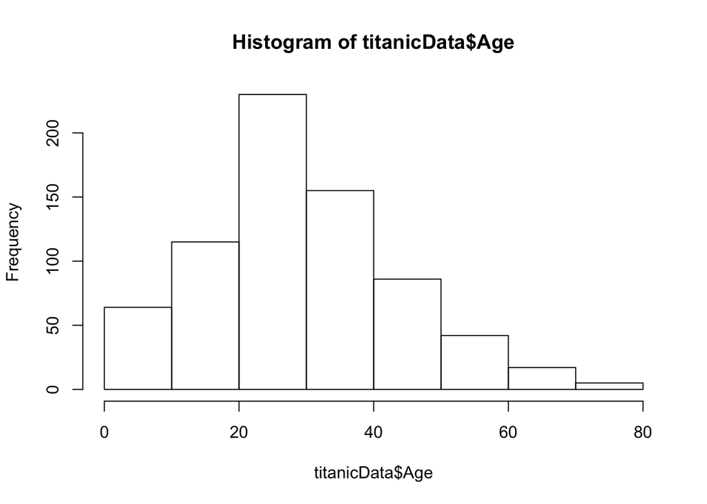